# Applied Statistics: HW1

Mikhail Ushakov

2024-04-04

```r
library(dplyr)
library(ggplot2)
library(vegan)
library(psych)
library(reshape2)
library(ggrepel)
library(ggsci)
```

# 1 EDA

## Load data

```r
data("BCI")
data("BCI.env")
```

## Explore species counts

NAs

```r
sum(is.na(BCI))
```

```
## [1] 0
```

The data consists of 50 rows representing 1 hectare plot and 225 columns with tree species counts on this plot.

Summary statistics of species counts for each plot

```r
describe(t(BCI))
```

```
##    vars   n mean    sd median trimmed mad min max range  skew kurtosis   se
## 1     1 225 1.99  4.33      0    0.85   0   0  25    25  3.15    10.49 0.29
## 2     2 225 1.93  4.79      0    0.71   0   0  36    36  3.96    18.41 0.32
## 3     3 225 2.06  5.44      0    0.73   0   0  39    39  4.39    21.51 0.36
## 4     4 225 2.26  5.25      0    0.94   0   0  39    39  3.96    19.01 0.35
## 5     5 225 2.24  5.62      0    0.96   0   0  55    55  5.31    37.97 0.37
## 6     6 225 1.83  4.99      0    0.61   0   0  44    44  4.91    29.88 0.33
## 7     7 225 1.85  4.68      0    0.70   0   0  38    38  4.30    22.40 0.31
## 8     8 225 1.92  4.85      0    0.80   0   0  41    41  4.93    30.23 0.32
## 9     9 225 1.82  5.61      0    0.67   0   0  65    65  7.58    73.95 0.37
## 10   10 225 2.15  5.51      0    0.83   0   0  46    46  4.89    29.91 0.37
## 11   11 225 1.78  4.62      0    0.71   0   0  41    41  4.86    29.54 0.31
## 12   12 225 1.63  4.92      0    0.54   0   0  46    46  5.94    42.60 0.33
## 13   13 225 1.82  4.44      0    0.81   0   0  39    39  5.18    34.74 0.30
## 14   14 225 1.95  4.50      0    0.86   0   0  33    33  4.12    20.18 0.30
```

[output cut: 36 more lines]

Make long df for convenience

```r
df <- cbind(plot = rownames(BCI), BCI)
df_long <- melt(df, id.vars = c("plot"), variable.name = "species", value.name = "counts")
```

Plot tree counts distribution

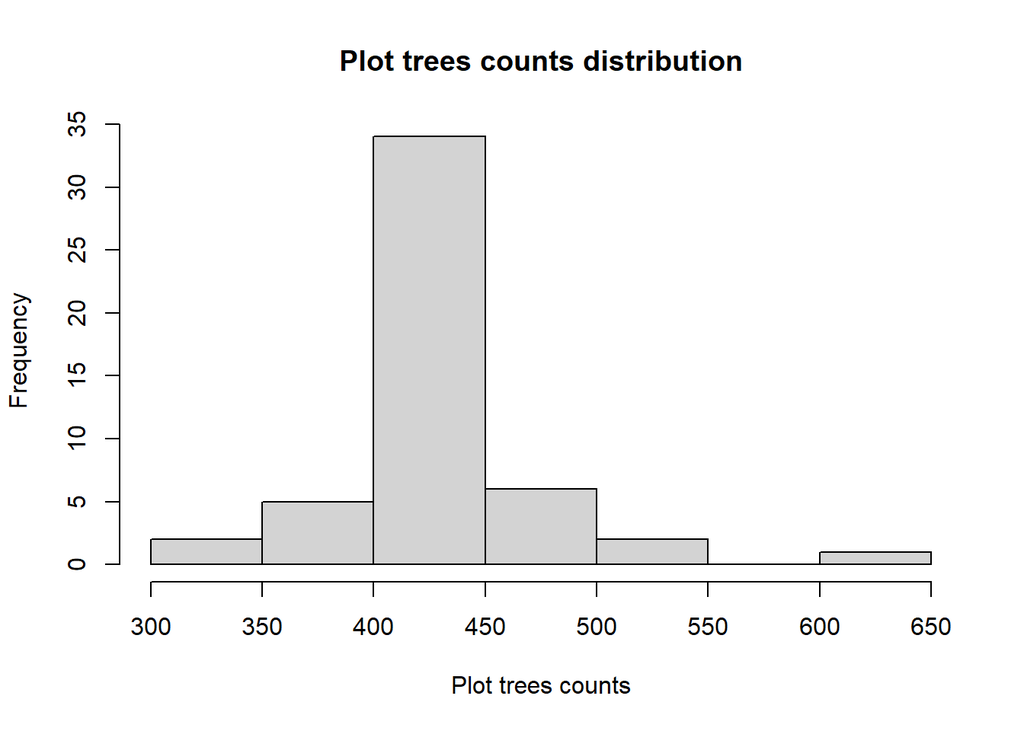

```r
rowSums(BCI) %>%  hist(xlab = "Plot trees counts", main = "Plot trees counts distribution")
```

Top 5 most abundant species by median

```r
df_long %>%
  group_by(species) %>%
  summarise(Mean = mean(counts), Median = median(counts)) %>%
  arrange(desc(Median)) %>%
  top_n(5)
```

```
## # A tibble: 5 × 3
##   species                 Mean Median
##   <fct>                  <dbl>  <dbl>
## 1 Faramea.occidentalis    34.3   34
## 2 Trichilia.tuberculata   33.6   32
## 3 Alseis.blackiana        19.7   16
## 4 Oenocarpus.mapora       15.8   15.5
## 5 Quararibea.asterolepis  14.5   14
```

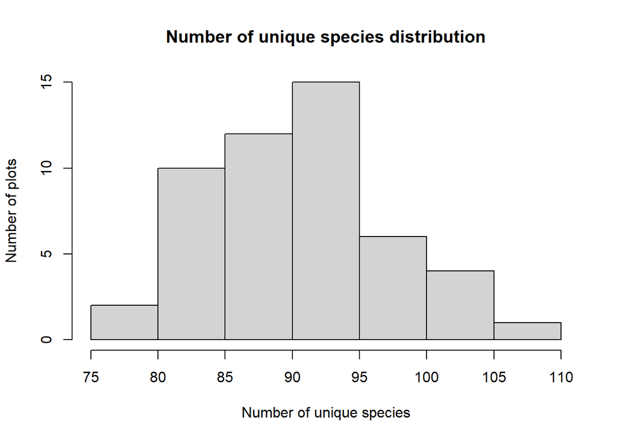

```r
df_long %>%
  group_by(plot) %>%
  filter(counts > 0) %>%
  count() %>%
  pull(n) %>%
  hist(
    main='Number of unique species distribution',
    xlab='Number of unique species',
    ylab='Number of plots'
    )
```

## Explore plot environmental variables

NAs

```r
sum(is.na(BCI.env))
```

```
## [1] 0
```

```r
head(BCI.env)
```

```
##   UTM.EW  UTM.NS Precipitation Elevation Age.cat Geology  Habitat Stream EnvHet
## 1 625754 1011569          2530       120      c3      Tb OldSlope    Yes 0.6272
## 2 625754 1011669          2530       120      c3      Tb   OldLow    Yes 0.3936
## 3 625754 1011769          2530       120      c3      Tb   OldLow     No 0.0000
## 4 625754 1011869          2530       120      c3      Tb   OldLow     No 0.0000
## 5 625754 1011969          2530       120      c3      Tb OldSlope     No 0.4608
## 6 625854 1011569          2530       120      c3      Tb   OldLow     No 0.0768
```

```r
str(BCI.env)
```

```
## 'data.frame':    50 obs. of  9 variables:
##  $ UTM.EW       : num  625754 625754 625754 625754 625754 ...
##  $ UTM.NS       : num  1011569 1011669 1011769 1011869 1011969 ...
##  $ Precipitation: int  2530 2530 2530 2530 2530 2530 2530 2530 2530 2530 ...
##  $ Elevation    : int  120 120 120 120 120 120 120 120 120 120 ...
##  $ Age.cat      : Factor w/ 2 levels "c2","c3": 2 2 2 2 2 2 2 2 2 2 ...
##  $ Geology      : Factor w/ 1 level "Tb": 1 1 1 1 1 1 1 1 1 1 ...
##  $ Habitat      : Factor w/ 5 levels "OldHigh","OldLow",..: 3 2 2 2 3 2 2 2 2 2 ...
##  $ Stream       : Factor w/ 2 levels "No","Yes": 2 2 1 1 1 1 2 2 1 1 ...
##  $ EnvHet       : num  0.627 0.394 0 0 0.461 ...
```

Thus, the only useful varaibles are Habitat, Stream and EnvHet.

```r
BCI.env %>% as.data.frame() %>% group_by(Habitat) %>% count()
```

```
## # A tibble: 5 × 2
## # Groups:   Habitat [5]
##   Habitat      n
##   <fct>    <int>
## 1 OldHigh      8
## 2 OldLow      26
## 3 OldSlope    12
## 4 Swamp        2
## 5 Young        2
```

```r
BCI.env %>% as.data.frame() %>% group_by(Stream) %>% count()
```

```
## # A tibble: 2 × 2
## # Groups:   Stream [2]
##   Stream     n
##   <fct>  <int>
## 1 No        43
## 2 Yes        7
```

# Ordination

## Calculate Bray-Curtis distances between plots

```r
dist <- vegdist(BCI, method = "bray")
```

## Scree plot

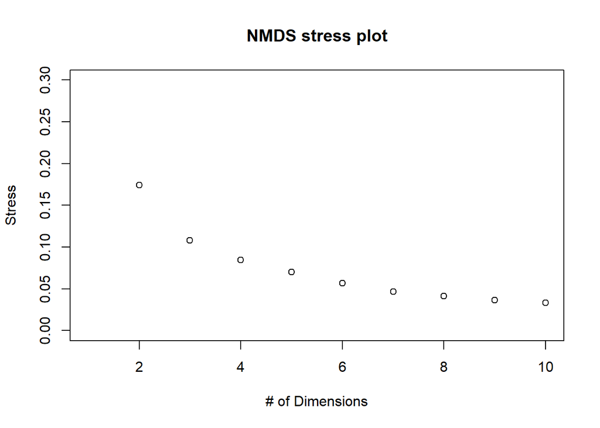

There is no good reflection point, so let’s take the number of dimensions of 2

## Simple ordination plot

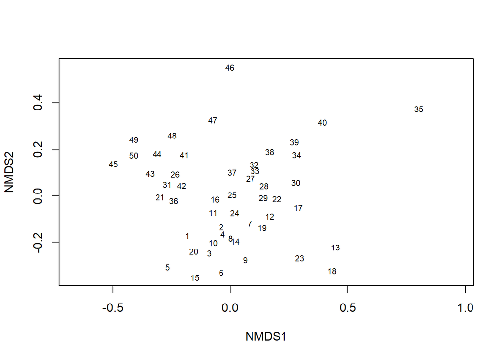

```r
ordiplot(NMDS2, display = "sites", type="t", cex=0.7)
```

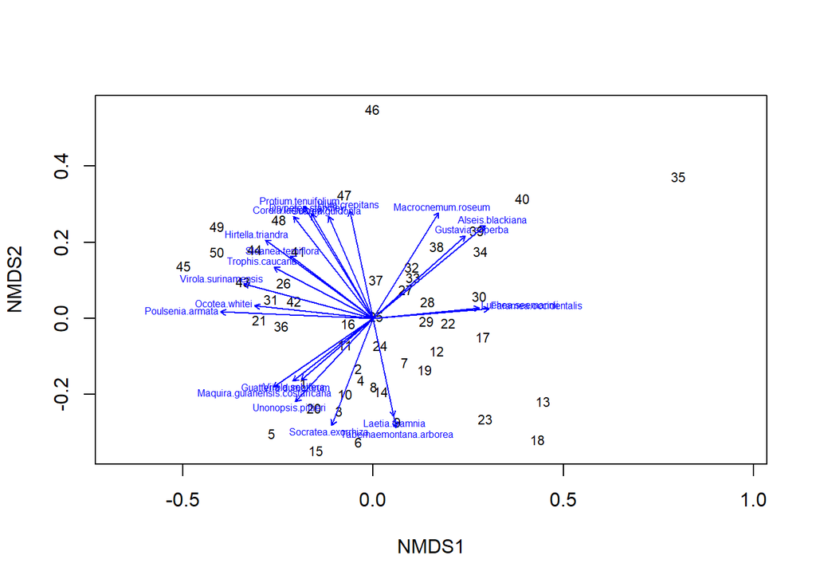

```r
ef <- envfit(NMDS2, BCI, permu = 999)
plot(NMDS2, type="t", display="sites")
plot(ef, p.max = 0.001, cex=0.5)
```

## Ordination plot with variables

[figure not shown]

```r
plot(NMDS2, type="n")
points(NMDS2, display="sites", pch = c(1, 2, 3, 4, 5) [as.numeric(BCI.env$Habitat)],col = c("black", "red") [as.numeric(BCI.env$Stream)])
legend(
  "topright",
  legend = c(levels(BCI.env$Habitat)),
  pch = c(1, 2, 3 ,4 ,5),
  title = "Habitat"
)

legend(
  "topleft",
  legend = c(levels(BCI.env$Stream)),
  pch = 1,
  title = "Stream",
  col = c("black", "red")
)

legend(
  "bottomleft",
  paste0("stress = ",round(NMDS2$stress, 3), cex = 1)
)
```

Hard to say that plots are well separated by “Habitat”, but it denitiely discriminates some groups. Seems that OldLow forests can have diversity similar to swamps and OldSlope forests. The second explanation is that it is the most abundant type in the dataset.

```r
mds_env <- data.frame(NMDS2$points)
mds_env$habitat <- as.factor(BCI.env$Habitat)
mds_env$envhet <- BCI.env$EnvHet
mds_env$envhet_size <- mds_env$envhet
mds_env$plot <- rownames(mds_env)
```

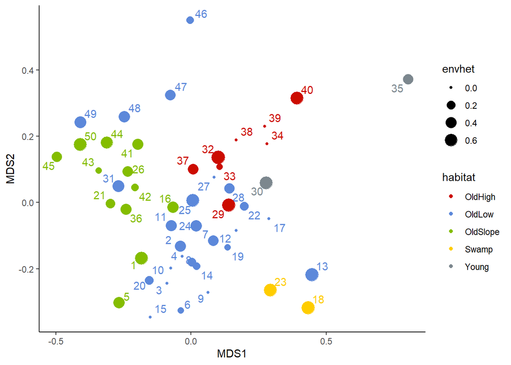

```r
mds_env %>%
  ggplot(aes(MDS1, MDS2, label = plot, col = habitat)) +
  geom_text_repel(show.legend = F) +
  geom_point(aes(size = envhet)) +
  scale_color_startrek() +
  theme_classic()
```

The same but more accurate picture we get with ggplot, showing now also heterogenity. We see that OldHigh and OldLow forests have big difference in heterogeneity and don’t see it in OldSlope forests. Young forests and Swamps have big heterogeneity.